# Final Project - Provider Relief Fund Analysis

Kashvi Sarup

## Introduction

During the COVID-19 pandemic, Congress created the Provider Relief Fund through the CARES act to support healthcare providers. For this analysis, I am using the Provider Relief Fund COVID-19 High Impact Payments dataset published on data.cdc.gov by the Health Resources and Services Administration (HRSA). Multiple providers and health systems received High Impact Provider Relief Fund (HIPRF) payments, distributed in different rounds of funding. This dataset provides information on those systems that received HIPRF payments, sorted by region and rounds of funding.

The objectives of this analysis are to:

1. Summarize the amount of Provider Relief Fund payments received by health systems
2. Examine how funding was distributed across states
3. Identify health systems that received the largest total payments

## Load Data

```r
prf_data <- read.csv("data/provider_relief_funds.csv")
str(prf_data)
```

```
## 'data.frame':    1197 obs. of  6 variables:
##  $ Name                  : chr  "ABBOTT NORTHWESTERN HOSPITAL" "ABINGTON - LANSDALE HOSPITAL (FKA LANSDALE HOSPITAL)" "ZUCKER HILLSIDE HOSPITAL" "ABINGTON HOSPITAL - JEFFERSON HEALTH (FKA ABINGTON MEMORIAL HOSPITAL)" ...
##  $ City                  : chr  "MINNEAPOLIS" "LANSDALE" "GLEN OAKS" "ABINGTON" ...
##  $ State                 : chr  "MN" "PA" "NY" "PA" ...
##  $ Returned..1st.Payment.: chr  "" "" "" "" ...
##  $ X1st.Round.Payment    : chr  "" "" "" "$   20,006,366" ...
##  $ X2nd.Round.Payment    : chr  "$   13,400,000.00" "$   10,700,000.00" "$   800,000.00" "$   22,511,377.79" ...
```

```r
prf_data <- prf_data |>
  mutate(
    X1st.Round.Payment = as.numeric(gsub("[\\$,]", "", X1st.Round.Payment)),
    X2nd.Round.Payment = as.numeric(gsub("[\\$,]", "", X2nd.Round.Payment))
  )
```

## Data Analysis - Top Recipients

```r
library(dplyr)

#Make table of top 10 recipients

top_recipients <- prf_data |>
  mutate(
    Total_Payment = X1st.Round.Payment + X2nd.Round.Payment
  ) |>
  arrange(desc(Total_Payment)) |>
  select(Name, City, State, Total_Payment) |>
  slice_head(n = 10)

knitr::kable(
  top_recipients,
  col.names = c("Hospital / Health System", "City", "State", "Total Payment"),
  caption = "Top 10 Recipients of Provider Relief Fund High-Impact Payments"
)
```

Top 10 Recipients of Provider Relief Fund High-Impact Payments

| Hospital / Health System | City | State | Total Payment |
| --- | --- | --- | --- |
| LONG ISLAND JEWISH MEDICAL CENTER | NEW HYDE PARK | NY | 278789857 |
| TISCH HOSPITAL | NEW YORK | NY | 217267090 |
| ST JOSEPHS UNIVERSITY MEDICAL CENTER (FKA ST JOSEPHS REGIONAL MEDICAL CENTER) | PATERSON | NJ | 186966890 |
| NEWYORK-PRESBYTERIAN/COLUMBIA UNIVERSITY IRVING MEDICAL CENTER | NEW YORK | NY | 169121122 |
| MONTEFIORE HOSPITAL - MOSES CAMPUS | BRONX | NY | 164943766 |
| MOUNT SINAI MEDICAL CENTER (AKA THE MOUNT SINAI HOSPITAL) | NEW YORK | NY | 153636402 |
| MAIMONIDES MEDICAL CENTER | BROOKLYN | NY | 153467879 |
| NEWYORK-PRESBYTERIAN/WEILL CORNELL MEDICAL CENTER | NEW YORK | NY | 129571122 |
| EINSTEIN MEDICAL CENTER PHILADELPHIA | PHILADELPHIA | PA | 118786104 |
| NYU WINTHROP HOSPITAL (FKA WINTHROP UNIVERSITY HOSPITAL) | MINEOLA | NY | 117767090 |

The table displays the ten hospitals or health systems that received the largest total Provider Relief Fund High-Impact payments, combining first- and second-round payments. It also shows each recipient’s city and state

## Data Analysis - Payments by State

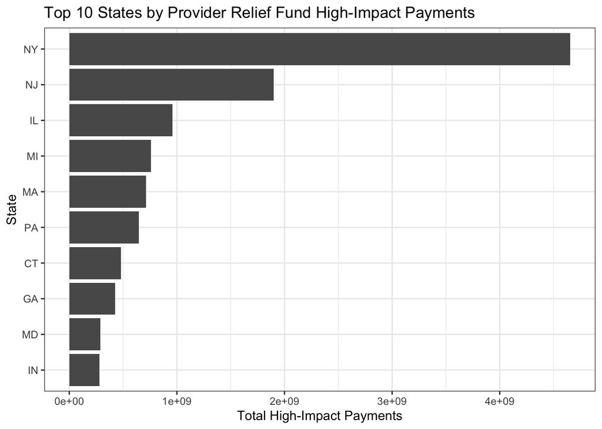

```r
#Make figure showing payments by state

state_payments <- prf_data |>
  mutate(
    Total_Payment = X1st.Round.Payment + X2nd.Round.Payment
  ) |>
  group_by(State) |>
  summarise(
    Total_Payment = sum(Total_Payment, na.rm = TRUE)
  ) |>
  arrange(desc(Total_Payment))

state_payments |>
  slice_head(n = 10) |>
  ggplot(aes(
    x = reorder(State, Total_Payment),
    y = Total_Payment
  )) +
  geom_col() +
  coord_flip() +
  labs(
    title = "Top 10 States by Provider Relief Fund High-Impact Payments",
    x = "State",
    y = "Total High-Impact Payments"
  ) +
  theme_bw()
```

The figure shows the ten states that received the largest total amount of payments. This provides a geographic view of how relief funding was distributed.